# Open Science and R

Symposium and Workshop

Stockholm, Swedish Museum of Natural History

Jan 23rd - Jan 25th 2017

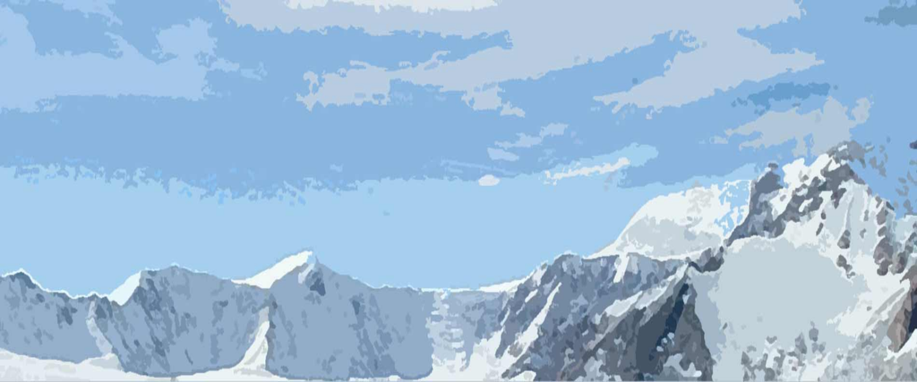

On the 23rd of January 2017 a symposium about Open Source systems in the public sector was held in Stockholm at the Swedish Museum of Natural History.

see [Open Source Systems in the Public Sector](http://www.nrm.se/english/researchandcollections/symposiumopensourcesystems.os2017.html) announcement

On the 24th - 25th of January 2017 a two-day workshop was arranged on the topic of using reproducible open research workflows with R for biodiversity analysis.

see the “[ROpenSci for all](http://www.nrm.se/english/researchandcollections/symposiumopensourcesystems.os2017.html)” announcement

# Symposium

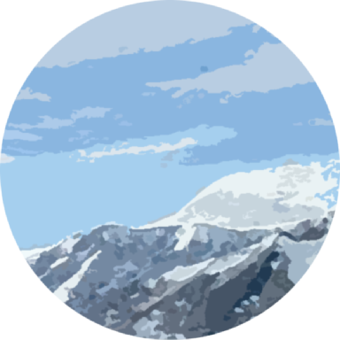

The symposium was given during one day and materials covered included serveral talks about using open source systems in the public sector.

More details about the full programme can be found in the program announcement. Links to presentations will be added below as presenters make their materials available …

[Symposium Programme](http://www.nrm.se/english/researchandcollections/symposiumopensourcesystems/program.9003769.html)

## Talks

Talks included these presentations:

- *Open Source Systems in the Public Sector* by Fredrik Ronquist, Head of the Department of Bioinformatics and Genetics, Swedish Museum of Natural History
- *Open Source Systems and Open Data at the Ministry of Culture in Sweden* by Sanja Halling, Digisam
- *Open Source Systems for Libraries in Sweden* by Jessica Andersson, Alingsås bibliotek, The Swedish Koha User Group
- *Open Source Systems in use at the National Library of Sweden* by Peter Krantz, National Library of Sweden
- *Open Source tools for collection management; the DINA web-based collection management system* by James Macklin, Agriculture and Agri-Food Canada
- *Adopting Atlas of Living Australia systems for Atlas of Living Scotland* by Ella Vogel, National Biodiversity Network
- *Open Source Systems serving Open Data in Environmental Management in Sweden* by Anna Otmalm, Swedish Environmental Protection Agency
- *Open Science with R* by Scott Chamberlain, rOpenSci

  see [PDF](https://rawgit.com/Open-Science-Nordics/public-sector-open-science/master/presentations-from-scott/Chamberlain.pdf)
- *R Tools for Biodiversity Informatics* by Markus Skyttner, Swedish Museum of Natural History

  see [Web slides](https://rawgit.com/Open-Science-Nordics/public-sector-open-science/master/presentations-from-markus/R-Tools-For-Biodiversity-Informatics.html)

# Workshop

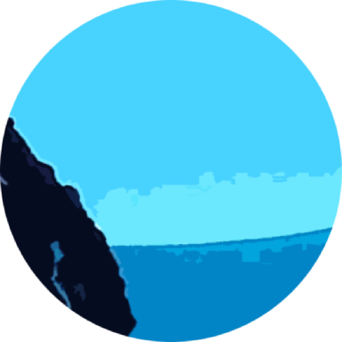

Participants in the two-day workshop - around 30 signed up - used GitHub for coordination and the presenters put their materials there including source code.

[Open Science Nordics at GitHub](https://github.com/Open-Science-Nordics)

## Presenters

Talks, demos and exercises were prepared by:

- Scott Chamberlain, [ROpenSci](https://ropensci.org)
- Ben Raymond, [ACE CRC](http://acecrc.org.au/)
- Alejandro Ruete, [Swedish University of Agricultural Sciences](http://www.slu.se/en/)
- Markus Skyttner, [Swedish Museum of Natural History](https://nrm.se)
- Alexander Zizka, [Gothenburg University](https://gu.se)

## Preparations

Participants were asked to prepare for the workshop by studying some relevant learning resources.

[see suggested readings](https://github.com/Open-Science-Nordics/workshop-materials/tree/master/introduction)

## Topics

Talks and demonstrations included various exercises related to topics in the area of scientific computation and biodiversity analysis with R and were tailored for the participants and their specific interest.

Topics presented in talks included these:

  [PDF](https://rawgit.com/Open-Science-Nordics/workshop-materials/master/talks/Chamberlain.pdf)
- Computing ignorance scores for primary biodiversity data - presented by Alejandro Ruete

  [see PDF](https://rawgit.com/Open-Science-Nordics/workshop-materials/master/talks/Ruete%20-%20Ignorance%20Maps%20for%20Oikos2017%20Github.pdf)
- Mirroreum and EU-BON R packages on using Docker for packaging and delivering reproducible research - presented by Markus Skyttner

  see [exercises at GitHub](https://rawgit.com/Open-Science-Nordics/workshop-materials/master/exercises/ropensci/00-introduction/intro.html)

  see [exercise](https://rawgit.com/Open-Science-Nordics/workshop-materials/master/exercises/ropensci/02-biodiversity/rgbif.html)

  see [exercises](https://github.com/Open-Science-Nordics/workshop-materials/tree/master/exercises/ropensci)
- Data from the Atlas of Living Australia platform - the APIs - and some ALA4R use case examples - presented by Ben Raymond

  see [PDF](https://rawgit.com/Open-Science-Nordics/workshop-materials/master/talks/raymond_martin-stockholm-jan-2017.pdf)
- Cleaning geospatial data and computing bias using speciesgeocodeR and sampbias R packages - presented by Alexander Zizka

  see [PDF](https://rawgit.com/Open-Science-Nordics/workshop-materials/master/talks/zizka_speciesgeocodeR_sampbias.pdf)

Various exercises (demonstrations and/or tasks with solutions) corresponding to these topics are available, including:

see [GitHub repo with all exercises](https://github.com/Open-Science-Nordics/workshop-materials/tree/master/exercises)

- How to get and clean data using `dplyr` and `tidyr` - an example with data wrangling involving data in spreadsheet format

  see use case with [local data - Swedish Butterfly data](https://github.com/Open-Science-Nordics/workshop-materials/tree/master/exercises/swedishbutterflies)
- How to get data from biodiversity data services through rOpenSci R packages and the ALA4R R packages

  see use case with [data from GBIF](https://github.com/Open-Science-Nordics/workshop-materials/tree/master/exercises/ropensci)

  see use case with [data from ALA](https://github.com/Open-Science-Nordics/workshop-materials/tree/master/exercises/ALA4RandWebAPIsExercises)
- How to get data directly from Web APIs - an exercise suggesting some R packages for directly accessing web data

  see [exercise](https://github.com/Open-Science-Nordics/workshop-materials/tree/master/exercises/ALA4RandWebAPIsExercises)
- How to rasterize primary biodiversity data

  see [tutorial](https://github.com/Open-Science-Nordics/workshop-materials/tree/master/exercises/DataHandlingTutorial)
- How to clean coordinates - a tutorial for using the “speciesgeocodeR” package

  see [tutorial](https://rawgit.com/Open-Science-Nordics/workshop-materials/master/exercises/speciesgeocoder_sampbias/speciesgeocodeR_coordinate_cleaning_exercise.html)
- How to compute sampling bias - a tutorial for using the “sampbias” package

  see [tutorial](https://rawgit.com/Open-Science-Nordics/workshop-materials/master/exercises/speciesgeocoder_sampbias/sampbias_exercise.html)
- Excercises involving hands-on work with some R packages bundling Swedish data

  see use case with [Swedish bird data](https://github.com/Open-Science-Nordics/workshop-materials/tree/master/exercises/swedishbirds)

# Links

Some suggested links on topics related to Reproducible Open Research:

- [ROpenSci - “Fostering open science and open data with R”](https://ropensci.github.io/ambassador-packet/slides/#ropensci)
- [Some challenges in doing reproducible research](https://ropensci.org/blog/2014/06/09/reproducibility/)
- [Towards Open Research](https://ndownloader.figshare.com/files/6739038)

> “The duty of the man who investigates the writings of scientists, if learning the truth is his goal, is to make himself an enemy of all that he reads, and … attack it from every side. He should also suspect himself as he performs his critical examination of it, so that he may avoid falling into either prejudice or leniency.”

# Feedback

If you attended this event, please make sure to fill out this quick survey with your feedback (see link below).

[Survey for feedback on “rOpenSci for all” workshop in Stockholm Jan 24th-25th 2017](https://www.surveymonkey.com/r/DV35GBX)

It is a short and small set of 10 questions, expected to take less than 5 minutes to fill out.